# Quantitative Designs

GE2021 Research Technology, Fall 2026

Chad (Chungil Chae)

cchae@kean.edu

Tue, 15 September 2026

# Learning Objectives(Pajo, 2022)

- Describe the purpose of exploratory, descriptive, and explanatory studies.
- Compare and contrast cross-sectional and longitudinal studies.
- Explain the differences between nomothetic research and idiographic research.
- Discuss each type of experimental design and its advantages and disadvantages.

## SHORT VIDEO INTRODUCTION

[video not shown]

# Categorizations of Research Studies

## Major decisions for designing a study.

- Visualize and conceptualize the study.
- Determine the practical details of the study.
- Learn about the possible errors that could occur.
- Finally, begin working.

## The first characteristic of research design involves what we are trying to accomplish in this study.

- Exploring a new relationship between variables? Describing a phenomenon in detail? Explaining an established relationship?
- Common distinctions of studies are based on trying to explore, explain, or describe something.

## Quantitative or Qualitative

- Qualitative.
  - Small samples; in-depth explorations; tends to construct a new theory.
  - Less design work, more data analysis.
  - Text, audio, image, and object analyses.
- Quantitative.
  - Large samples; clean measures to test hypothesis; tests an established theory.
  - Intensive design work, less data analysis.
  - Statistical analyses.

## Exploratory Studies—Answering “What?”

- Exploratory studies are often used to investigate a new topic of research, a new thread of previously established relationships, a new methodology, a new instrument of data collection, or to gain a deeper understanding on a specific population.
- Useful as initiators for larger, complex studies. Aim at investigating, exploring, or figuring out a new, innovative thread of knowledge.

## Descriptive Studies—Answering “How?”

- Descriptive studies allow researchers to focus on describing a phenomenon or understanding the details about people’s experiences of a particular event.
- Awareness of the difficulties that a specific group of people is experiencing may reveal possible ways of intervening to help the group in need.
- Generally qualitative as it is often necessary to gather in-depth data and allow participants the flexibility of expressing their feelings and situations in detail.

## Explanatory Studies—Answering “Why?”

- Explanatory studies are reinforcing studies. They focus on explaining the reasons behind a phenomenon, relationship, or event.
- Seek to explain the reasons behind an already known and/or established relationship.
- May be quantitative or qualitative depending on the researcher, but are usually quantitative.

# Cross-Sectional Versus Longitudinal Studies

## Cross-Sectional Studies

- Cross-sectional is the name for studies that collect data only once, a simple snapshot of data collected at one point in time.
  - For example, collecting information from participants who have purchased an expensive car in the last year.
- Refers to one shot of data collection, without any follow-up questions; useful when collecting data from a large number of participants.
- Difficult to establish any cause-effect relationships because all the variables are collected at the same time.

## Longitudinal Studies

- Longitudinal studies collect data at different points in time, which helps the data to be more accurate and avoid or minimize errors like inaccurate responses.
  - For example, we may want to know the long-term effects of a specific medication given to children.
- These different data collection points are called waves. The first data collection is often called base wave or wave I, typically continuing with wave II, wave III, and so on.
- Desirable for various topics as they are known for their accuracy.
- Types of longitudinal studies:
  - Panel studies follow and accumulate data from the same participants over a period of time.
  - Trend studies collect data at different points in time from different participants of the same population.
  - Cohort studies follows the same cohort of people over time. Includes a broader definition (such as being born, married, or giving birth in the same year) and are not the same people.

# Causality in Research

- An important feature of design is determining the type of relationship the study will investigate.
- Researchers often attempt to establish a causal relationship between variables of interest, which refers to attempts to determine that one or more variables (the independent variables), have caused the changes in another variable (the dependent variable).

## Nomothetic Research

- Nomothetic research aims at arriving at causal relationships that are easily applied to the population at large. Often quantitative because of its large scope.
  - Such as establishing that people with a higher education level will likely earn a higher salary.
- To establish nomothetic causality, a research study needs to establish three criteria:
  - Correlation: variables we are studying are related to each other; the changes in our independent variable should go hand in hand with changes in the dependent variable.
  - Time order: determines the actual order of changes from one variable to another; changes in the independent variable happen first in time and are accompanied by changes in the dependent variable happening later in time.
  - Non-spuriousness: A spurious relationship is explained away by a third variable that may have not been considered. Claiming nomothetic causality requires a non-spurious relationship.

## Idiographic Research

- Idiographic research attempts to explain the entire realm of influences and every possible detail that has influenced a particular phenomenon or event for an individual. Often qualitative in nature.
- It is time-consuming because it can investigate only one individual or event at a time because of its depth in truly capturing the information.
- Fuels later nomothetic research, but it is an important tool used to investigate a problem at an individual level before generalizing society at large.

# Experimental Designs

- An experimental design is a study that includes an experiment and then analyzes the results.

## Classic Experimental Design

- Experimental design refers to the presence of a test, experiment, intervention, or some form of manipulation happening at the time of data collection.
- Three requirements must be fulfilled in order to conduct an experimental design:
  - 1. the presence of a control group and an experimental group,
  - 2. randomly assigning participants to the control and experimental groups, and
  - 3. collecting data before and after the experiment, also known as pre- and posttesting.

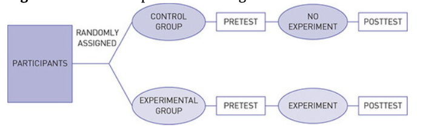

- Experimental and Control Groups
  - The experimental group is undergoing some form of experimentation, such as training, taking a test or a drug, or some other form of intervention.
  - The control group do everything the participants in the experimental group do, but are not given any test, drug, intervention, or manipulation, although they may be told that they are.
  - The control group controls for confounding or disturbing variables, giving researchers confidence that findings are accurate and the outcome was a consequence of the experiment rather than extraneous reasons.
- Random Assignment
  - When ready to collect data, first one should randomly place the participants into the experimental group and the control group.
  - Minimizes the potential of characteristics to be the determining factor.
  - Random select can be accomplished in a number of ways including drawing numbers or using a computer number generator.
  - The researcher is usually aware of which group participants are assigned, whereas the participants are not aware. In instances where neither is aware, the studies are known as double-blind studies.
- Pre- and Posttesting
  - Researchers need to pretest the participants and posttest them to figure out the actual results of our study, otherwise they may not notice any changes.
  - The pretest and the posttest cannot be different or it may manipulate the outcome.

## Solomon Four-Group Experimental Design

- The Solomon four-group experimental design is a type of experimental design that helps to minimize measurement errors.
  - Protects the study from the biases of pretest.
  - Uses two experimental groups and two control groups.
  - One experimental and one control group take the pretest, the other two groups are subjected only to the intervention or the placebo and do not take the pretest.
  - The differences in results can clearly show whether the pretest is influencing the results of the study.

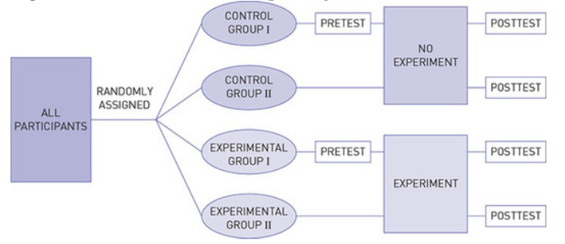